# More plotting functions in R

# 5 Histograms and Quantile-Quantile plots

Let’s explore some other useful plots for data exploration: histograms and Quantile-Quantile plots. Quantiles are cut points dividing the range of a probability distribution or observations into contiguous intervals. We can use normal QQ plots to evaluate normality, with the data plotted against theoretical quantiles , and plot the quantiles of one population against another to see if they have similar distributions (even if observed values are different). Histograms are used to evaluate distribution of data, and evaluate normality, skewness, and can indicate outliers. We will use the iris data for this.

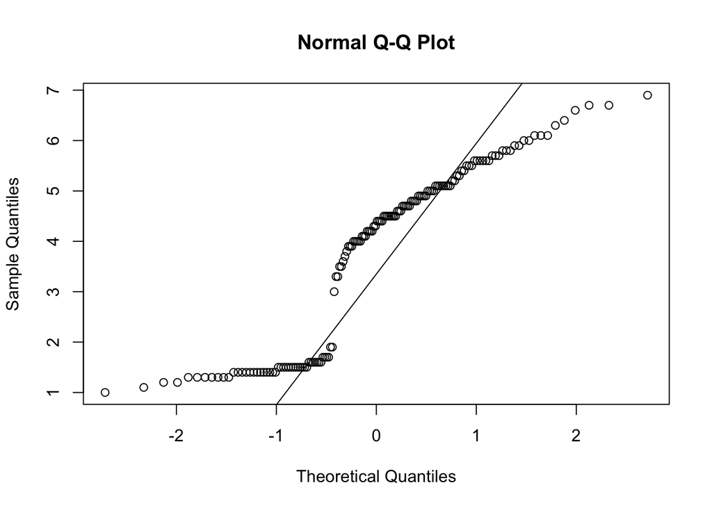

```r
# Here's the petal length data plotted against theoretical normal quantiles
# We would use this to check normality
qqnorm(iris$Petal.Length)
qqline(iris$Petal.Length) # add a line-yikes!
```

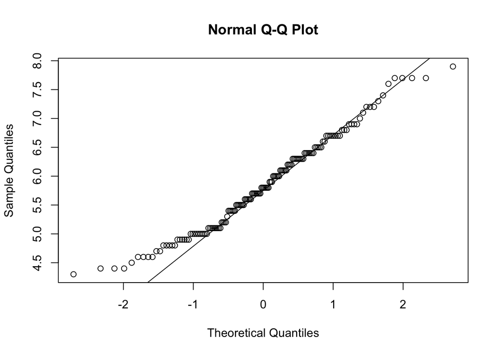

```r
# what should a qqnorm plot look like?
# let's plot data from the sepals
qqnorm(iris$Sepal.Length)
qqline(iris$Sepal.Length) # better
```

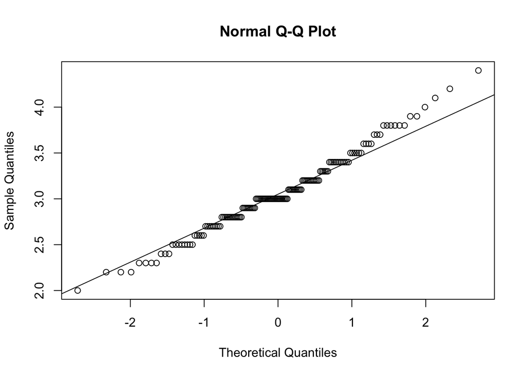

```r
qqnorm(iris$Sepal.Width)
qqline(iris$Sepal.Width)
```

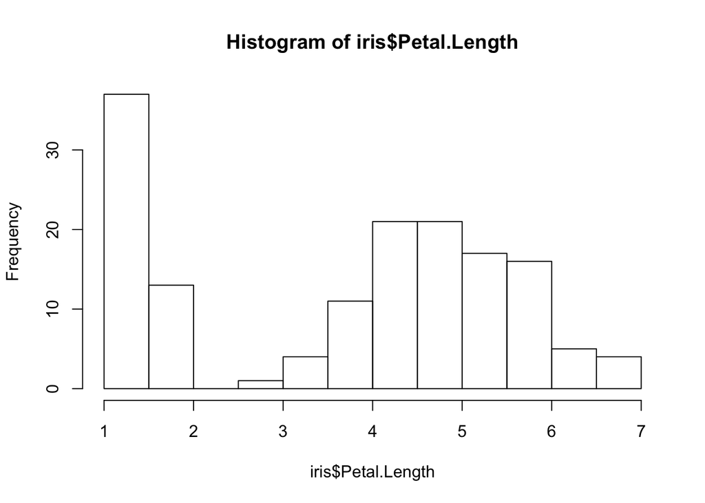

```r
# you get this step-like pattern because data are collected in even increments (or data that are rounded)

# plot a histogram of the petal length data
hist(iris$Petal.Length)
```

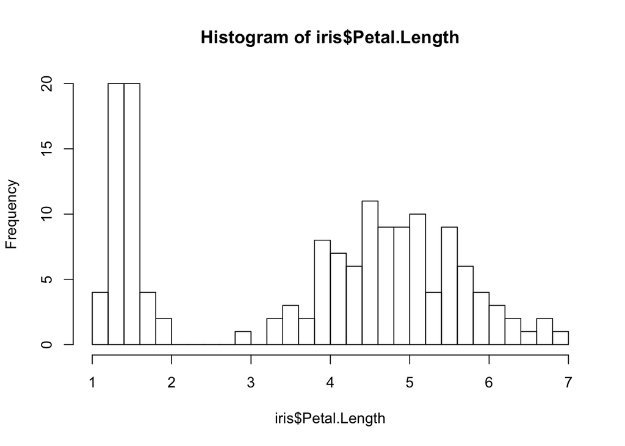

```r
# increase the number of bars using 'breaks='
hist(iris$Petal.Length,
     breaks = 30)
```

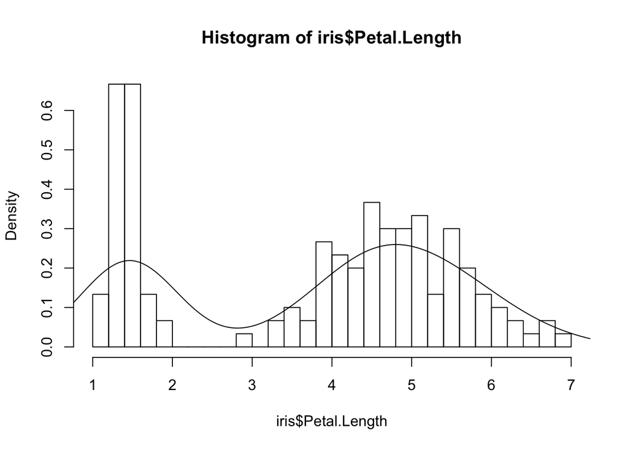

```r
# so far we have been plotting frequencies, we can also plot the probability distribution by specifying 'prob=TRUE' ; note the difference on y axis
hist(iris$Petal.Length,
     breaks = 30,
     prob = TRUE)

# you can plot a density curve over this:
lines(density(iris$Petal.Length))
```

# 6 Exercise

Either go back to the barplot and see what happens if you specify `beside=FALSE` and `horiz=TRUE` or use qqplots or histograms to evaluate whether the other iris variables are normally distributed. You can use `names(iris)` to see the variable names.

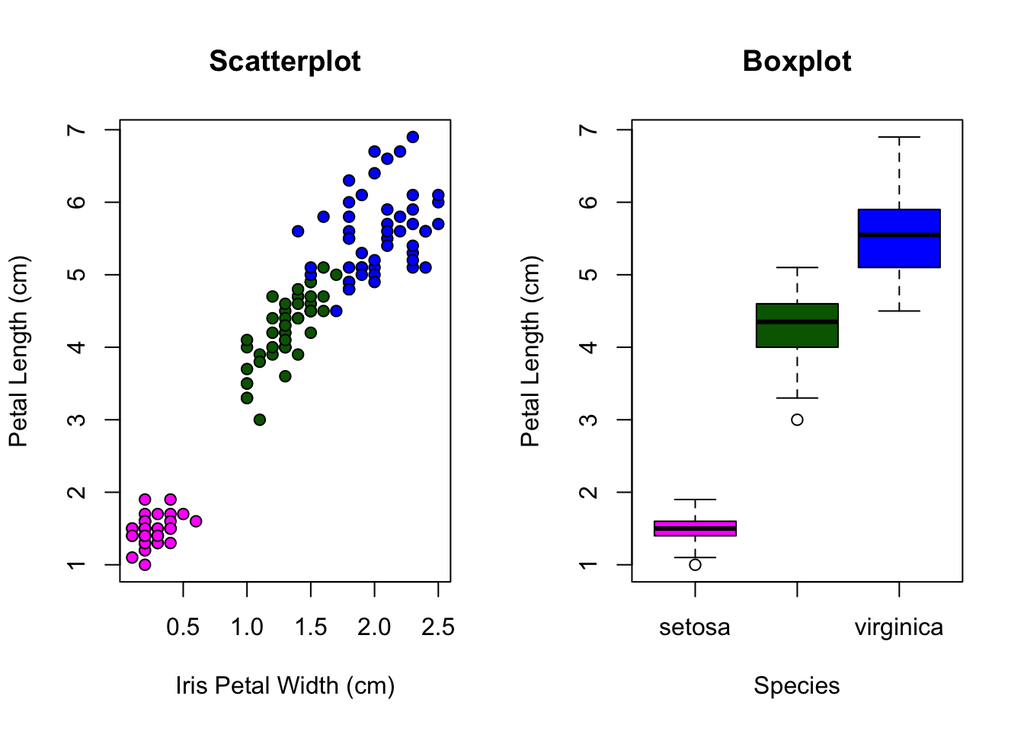

```r
opar <- par ## make a copy of current settings so you can reset your graphing parameters when you are done messing around below (this says: save the current parameters as something called 'opar')

par(mfrow = c(1, 2)) # layout plot area with 1 row, 2 columns

# we'll just combine two plots we have made before
plot(iris$Petal.Length ~ iris$Petal.Width,
     xlab = "Iris Petal Width (cm)",
     ylab = "Petal Length (cm)",
     main = "Scatterplot",
     pch = 21,
     bg = c("magenta", "dark green", "blue")[unclass(iris$Species)]
)
# For symbols 21 through 25, specify border color (col=) and fill color (bg=)

boxplot(iris$Petal.Length ~ iris$Species,
        col = c("magenta", "dark green", "blue"),
        main = "Boxplot", xlab = "Species", ylab = "Petal Length (cm)"
)
```

# 7 Here we will provide some code to evaluate and plot correlations among variables

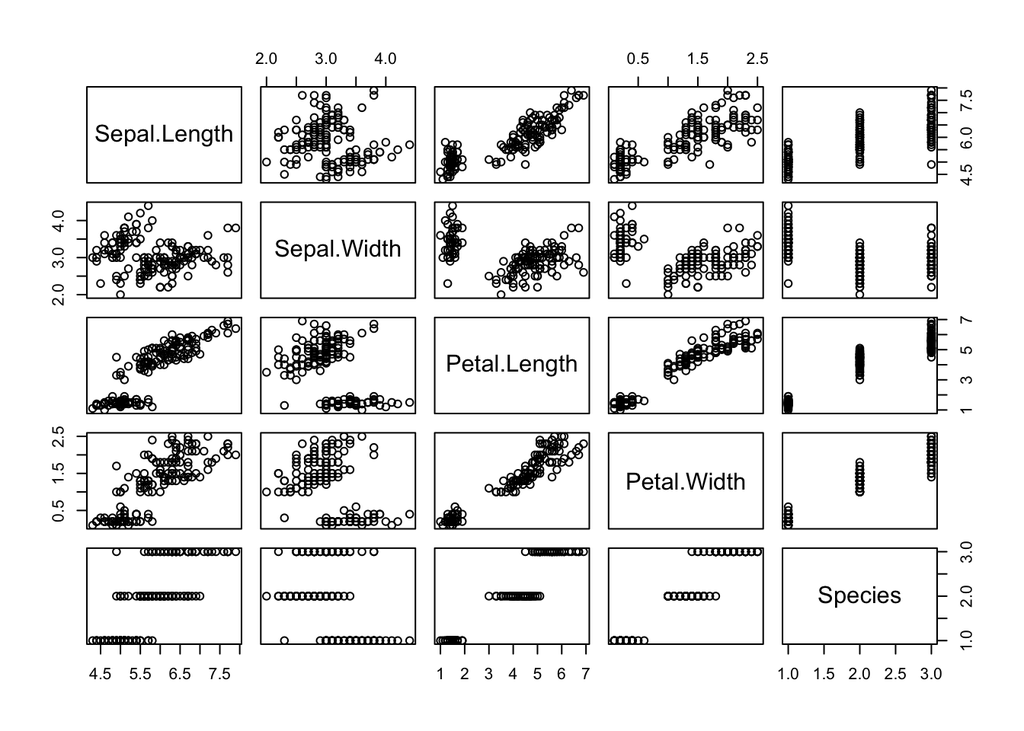

```r
#  the quick and dirty way to look at correlation between multiple variables
pairs(iris)
```

```r
# return correlation values between two variables; default is Pearson's
cor(iris$Petal.Width,
    iris$Petal.Length)
```

```
## [1] 0.9628654
```

```r
# you can specify other methods of estimating correlation (or do it yourself!)
cor(iris$Petal.Width,
    iris$Petal.Length,
    method = "spearman")
```

```
## [1] 0.9376668
```

```r
cor(iris$Petal.Width,
    iris$Petal.Length,
    method = "kendall")
```

```
## [1] 0.8068907
```

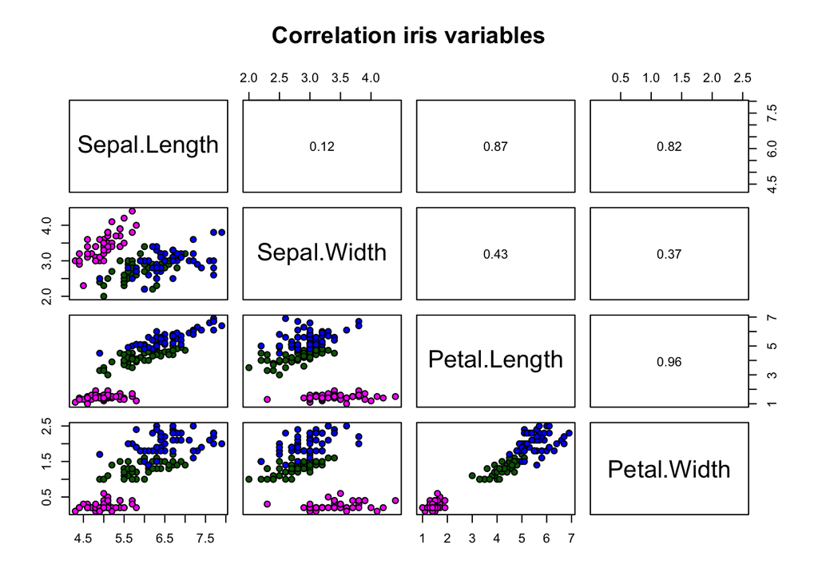

```r
# I'm not going to fully explain this since we haven't talked about functions, but here's a function you can use to calculate Pearson correlation and plot it alongside variables.  Any time you see {} make sure to run the whole piece of code together
panel.pearson <- function(x, y, ...) {
  horizontal <- (par("usr")[1] + par("usr")[2]) / 2
  vertical <- (par("usr")[3] + par("usr")[4]) / 2
  text(horizontal, vertical, format(abs(cor(x, y)), digits = 2))
}

# use the pairs function again, but this time make it look nice, add colors, and have the upper set of panels show the panel.pearson function from above
pairs(iris[1:4],
      main = "Correlation iris variables", pch = 21,
      bg = c("magenta", "dark green", "blue")[unclass(iris$Species)],
      upper.panel = panel.pearson
)
## iris[1:4] specifies just use first 4 variables (row and column)

## alternatively, you can specify which variables you want to plot (it is sometimes better to write them out this way so you can keep track if you are working with multiple datasets with different numbers of variables)--this will make the same plot as above
pairs(iris[c("Sepal.Length", "Sepal.Width", "Petal.Length", "Petal.Width")],
      main = "Correlation iris variables", pch = 21,
      bg = c("magenta", "dark green", "blue")[unclass(iris$Species)],
      upper.panel = panel.pearson
)
```

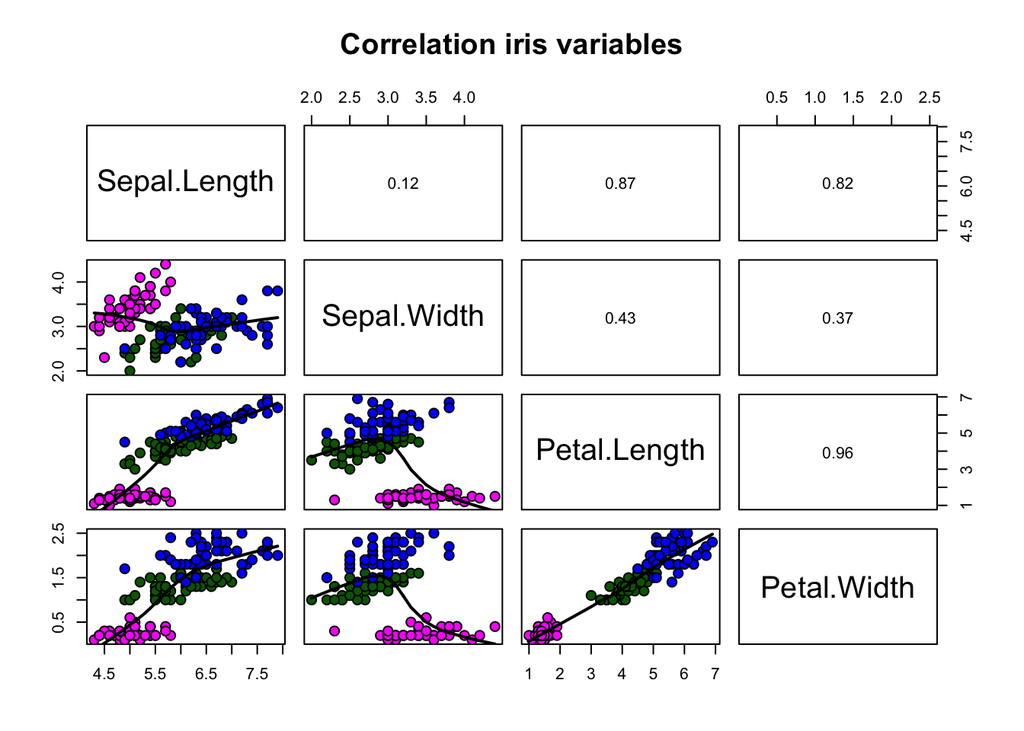

```r
## here's another function to add smoothed (lowess) lines to a pairs correlation plot
panel.smooth2 <- function(x, y, col = par("col"), bg = NA, pch = par("pch"),
                          cex = 1, col.smooth = "red", span = 2 / 3, iter = 3, ...) {
  points(x, y, pch = pch, col = col, bg = bg, cex = cex)
  ok <- is.finite(x) & is.finite(y)
  if (any(ok)) {
    lines(stats::lowess(x[ok], y[ok], f = span, iter = iter),
          col = 1, lwd = 2, ...
    )
  }
}

# then run the pairs function again, specifying the smoothing line in the lower panels to help you visualize the relationship between variables
pairs(iris[1:4],
      main = "Correlation iris variables", pch = 21,
      bg = c("magenta", "dark green", "blue")[unclass(iris$Species)],
      cex = 1.3, # I made the points bigger because they were hard to see
      upper.panel = panel.pearson,
      lower.panel = panel.smooth2
)
```

# 8 whew, thanks for hanging in there! Have a donut…

If you go online, you will see many, many more things people have done with these iris data! This is not even one of the better ones, it was just one that let me copy it’s location from the internet :)

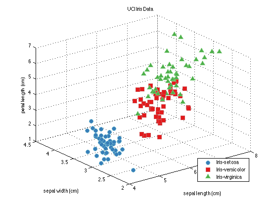